# DT2

Daniel Myung

2026-04-13

← Back to Main Report

In this section, we apply two tree-based classifiers to predict whether an individual has a history of mental illness: a C5.0 Decision Tree and a Random Forest.

The C5.0 decision tree recursively partitions the data based on the feature that best separates the classes at each node, producing an interpretable set of if-else rules. The Random Forest extends this idea by building an ensemble of 500 decision trees, each trained on a random bootstrap sample of the data and considering only a random subset of features at each split.

For the Random Forest, a custom classification threshold of 0.34 is also explored to improve sensitivity toward the minority class.

```r
library(C50)
library(caret)
set.seed(12345)

# Using the original data as requested
train <- readRDS("train_original.rds")
test <- readRDS("test_original.rds")

# C5.0 requires the target to be a factor
train$History.of.Mental.Illness <- as.factor(train$History.of.Mental.Illness)
test$History.of.Mental.Illness <- as.factor(test$History.of.Mental.Illness)

# Define the features (X) and the target (y)
# We exclude the target column from the training features
features <- train[, names(train) != "History.of.Mental.Illness"]
target   <- train$History.of.Mental.Illness

# Create the C5.0 model

c50_model <- C5.0(features, target, trials = 1)

# If you want to be explicit about the package:
# c50_model <- C50::C5.0(features, target, trials = 1)

summary(c50_model)
```

```
##
## Call:
## C5.0.default(x = features, y = target, trials = 1)
##
##
## C5.0 [Release 2.07 GPL Edition]      Wed Apr 15 03:54:44 2026
## -------------------------------
##
## Class specified by attribute `outcome'
##
## Read 20688 cases (15 attributes) from undefined.data
##
## Decision tree:
##  No (20688/6372)
##
##
## Evaluation on training data (20688 cases):
##
##      Decision Tree
##    ----------------
##    Size      Errors
##
##       1 6372(30.8%)   <<
##
##
##     (a)   (b)    <-classified as
##    ----  ----
##   14316          (a): class No
##    6372          (b): class Yes
##
##
## Time: 0.0 secs
```

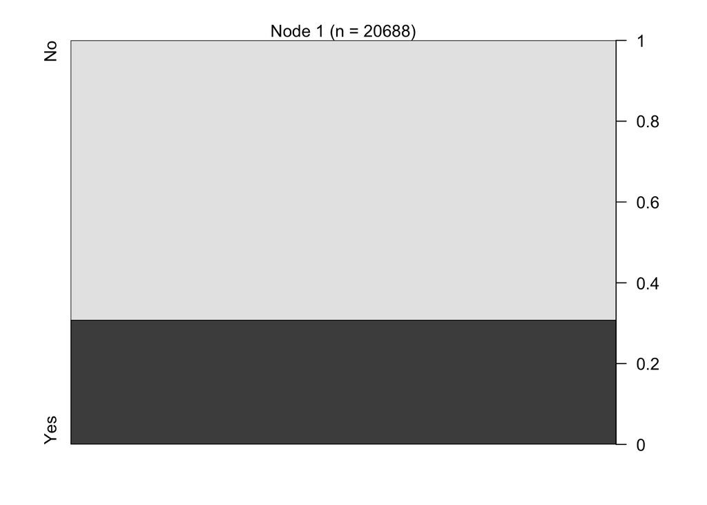

```r
# Note: C5.0 trees can get very large, plot may be dense
plot(c50_model)
```

```r
# Predict Class
c50_pred <- predict(c50_model, test, type = "class")

# Predict Probabilities (for ROC curves later)
c50_prob <- predict(c50_model, test, type = "prob")

head(c50_pred)
```

```
## [1] No No No No No No
## Levels: No Yes
```

```r
head(c50_prob)
```

```
##               No       Yes
## 99138  0.6919954 0.3080046
## 266096 0.6919954 0.3080046
## 128534 0.6919954 0.3080046
## 146588 0.6919954 0.3080046
## 344862 0.6919954 0.3080046
## 168123 0.6919954 0.3080046
```

```r
confusionMatrix(c50_pred, test$History.of.Mental.Illness, positive = "Yes")
```

```
## Confusion Matrix and Statistics
##
##           Reference
## Prediction    No   Yes
##        No  14323  6365
##        Yes     0     0
##
##                Accuracy : 0.6923
##                  95% CI : (0.686, 0.6986)
##     No Information Rate : 0.6923
##     P-Value [Acc > NIR] : 0.5034
##
##                   Kappa : 0
##
##  Mcnemar's Test P-Value : <2e-16
##
##             Sensitivity : 0.0000
##             Specificity : 1.0000
##          Pos Pred Value :    NaN
##          Neg Pred Value : 0.6923
##              Prevalence : 0.3077
##          Detection Rate : 0.0000
##    Detection Prevalence : 0.0000
##       Balanced Accuracy : 0.5000
##
##        'Positive' Class : Yes
##
```

```r
saveRDS(c50_model, file = "c50_model.rds")
saveRDS(c50_pred, file = "c50_pred.rds")
# Saving the 'Yes' probability vector specifically for consistency with your other models
saveRDS(c50_prob[, "Yes"], file = "c50_prob_mental_illness.rds")
```

The C5.0 tree produces a degenerate result: it predicts “No” for every single observation, achieving an accuracy of 69.2% that exactly matches the No Information Rate. The Kappa of 0 confirms the model has learned nothing beyond the majority class baseline, with sensitivity of 0% and specificity of 100%. The tree collapsed to a single root node, meaning it found no split informative enough to justify branching: this is a direct consequence of the class imbalance overwhelming the algorithm.

```r
library(randomForest)
```

```r
library(caret)

# 1. LOAD DATA
# Using the original data as requested for tree-based models
train <- readRDS("train_original.rds")
test  <- readRDS("test_original.rds")

# 2. PRE-PROCESSING
# Ensure target variable is a factor for classification
train$History.of.Mental.Illness <- as.factor(train$History.of.Mental.Illness)
test$History.of.Mental.Illness  <- as.factor(test$History.of.Mental.Illness)

# Define the features (X) and the target (y)
features <- train[, names(train) != "History.of.Mental.Illness"]
target   <- train$History.of.Mental.Illness

# 3. TRAIN RANDOM FOREST
# ntree: number of trees (500 is standard)
# importance: TRUE allows us to see which variables matter most
set.seed(123) # For reproducibility
rf_model <- randomForest(features, target, ntree = 500, importance = TRUE)

# View model summary and variable importance
print(rf_model)
```

```
##
## Call:
##  randomForest(x = features, y = target, ntree = 500, importance = TRUE)
##                Type of random forest: classification
##                      Number of trees: 500
## No. of variables tried at each split: 3
##
##         OOB estimate of  error rate: 31.69%
## Confusion matrix:
##        No Yes class.error
## No  13849 467  0.03262084
## Yes  6089 283  0.95558694
```

```r
importance(rf_model)
```

```
##                                      No         Yes MeanDecreaseAccuracy
## Age                          20.7418143 -14.7266657           12.5259348
## Marital.Status               18.5635744 -11.5672187           13.4170243
## Education.Level              22.1190585 -18.5167950           19.6437118
## Number.of.Children           11.0943628  -6.5784706            7.1359533
## Smoking.Status                8.6349930   2.1876637            9.0798646
## Physical.Activity.Level      18.4173885 -10.4469346           12.4406370
## Employment.Status            11.1749660  -3.0127513           14.7188414
## Income                       25.9000916  -7.8532227           33.1866686
## Alcohol.Consumption          -0.7449283   2.5787462            0.8030043
## Dietary.Habits               12.2000460  -9.2767930            7.7250595
## Sleep.Patterns                9.5622541  -5.9221969            5.7269345
## History.of.Substance.Abuse   -0.5375864   1.7373908            0.5501725
## Family.History.of.Depression  0.5466023   3.3292428            2.4027645
## Chronic.Medical.Conditions    0.8122588   0.6978602            1.0884126
##                              MeanDecreaseGini
## Age                                 1383.9670
## Marital.Status                       304.8165
## Education.Level                      399.6494
## Number.of.Children                   471.4515
## Smoking.Status                       299.2529
## Physical.Activity.Level              328.9536
## Employment.Status                    109.4324
## Income                              1844.8068
## Alcohol.Consumption                  373.3191
## Dietary.Habits                       294.3869
## Sleep.Patterns                       311.8110
## History.of.Substance.Abuse           219.3671
## Family.History.of.Depression         201.3510
## Chronic.Medical.Conditions           209.6564
```

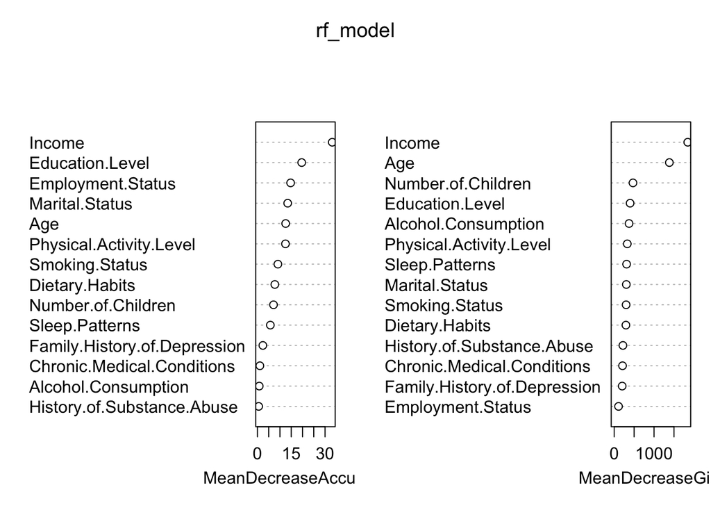

```r
varImpPlot(rf_model)
```

```r
# 4. PREDICTIONS
# Ensure test features match training features
test_features <- test[, names(test) != "History.of.Mental.Illness"]

# Predict Class (Default 0.5 threshold)
rf_pred <- predict(rf_model, test_features, type = "class")

# Predict Probabilities
rf_prob <- predict(rf_model, test_features, type = "prob")

# 5. EVALUATION
# Using the 0.5 threshold first
cat("\n--- RANDOM FOREST (Default 0.5 Threshold) ---\n")
```

```
##
## --- RANDOM FOREST (Default 0.5 Threshold) ---
```

```r
confusionMatrix(rf_pred, test$History.of.Mental.Illness, positive = "Yes")
```

```
## Confusion Matrix and Statistics
##
##           Reference
## Prediction    No   Yes
##        No  13969  6121
##        Yes   354   244
##
##                Accuracy : 0.687
##                  95% CI : (0.6806, 0.6933)
##     No Information Rate : 0.6923
##     P-Value [Acc > NIR] : 0.9518
##
##                   Kappa : 0.0182
##
##  Mcnemar's Test P-Value : <2e-16
##
##             Sensitivity : 0.03833
##             Specificity : 0.97528
##          Pos Pred Value : 0.40803
##          Neg Pred Value : 0.69532
##              Prevalence : 0.30767
##          Detection Rate : 0.01179
##    Detection Prevalence : 0.02891
##       Balanced Accuracy : 0.50681
##
##        'Positive' Class : Yes
##
```

```r
# 6. OPTIONAL: APPLY CUSTOM THRESHOLD (0.34)
# Since you mentioned the 0.5 threshold predicts "All No", this 0.34 shift
# will make the model more sensitive.
rf_pred_34 <- factor(ifelse(rf_prob[, "Yes"] > 0.34, "Yes", "No"), levels = c("No", "Yes"))

cat("\n--- RANDOM FOREST (Adjusted 0.34 Threshold) ---\n")
```

```
##
## --- RANDOM FOREST (Adjusted 0.34 Threshold) ---
```

```r
confusionMatrix(rf_pred_34, test$History.of.Mental.Illness, positive = "Yes")
```

```
## Confusion Matrix and Statistics
##
##           Reference
## Prediction    No   Yes
##        No  10644  4137
##        Yes  3679  2228
##
##                Accuracy : 0.6222
##                  95% CI : (0.6155, 0.6288)
##     No Information Rate : 0.6923
##     P-Value [Acc > NIR] : 1
##
##                   Kappa : 0.0951
##
##  Mcnemar's Test P-Value : 2.351e-07
##
##             Sensitivity : 0.3500
##             Specificity : 0.7431
##          Pos Pred Value : 0.3772
##          Neg Pred Value : 0.7201
##              Prevalence : 0.3077
##          Detection Rate : 0.1077
##    Detection Prevalence : 0.2855
##       Balanced Accuracy : 0.5466
##
##        'Positive' Class : Yes
##
```

```r
# 7. SAVE OUTPUTS
saveRDS(rf_model, file = "rf_model.rds")
saveRDS(rf_pred_34, file = "rf_pred.rds") # Saving the sensitive version for the council
saveRDS(rf_prob[, "Yes"], file = "rf_prob_mental_illness.rds")

# Preview results
head(rf_prob)
```

```
##           No   Yes
## 99138  0.848 0.152
## 266096 0.750 0.250
## 128534 0.730 0.270
## 146588 0.690 0.310
## 344862 0.858 0.142
## 168123 0.870 0.130
```

At the default 0.5 threshold, the Random Forest suffers from the same majority-class bias, with a Kappa of just 0.018 and sensitivity of only 3.8%. Lowering the threshold to 0.34 meaningfully improves performance: Kappa rises to 0.095 and sensitivity reaches 35%, at the cost of reduced specificity (74.3%). This represents a more balanced trade-off and is the more useful configuration for this task.

At this point, the GLM remains the best overall model with a Kappa of 0.143 and the most balanced sensitivity (43.8%) and specificity (70.8%). The Random Forest at the adjusted threshold is second, followed by KNN, while the C5.0 tree fails entirely.